# Bioinformática aplicada à taxonomia (monographaR)

Marcelo Reginato

Bioinformática aplicada à sistemática, biogeografia e macroevolução

Novembro / 2018

## Utilizando o monographaR

A utilização das funções do pacote monographaR é bastante simples. Geralmente, é preciso rodar um comando para importar os dados com uma função básica do R (e.g., read.csv, read.table, read.delim, …) e um segundo comando para realizar uma tarefa disponível no pacote.

No final deste tutorial tem um modelo de script para rodar alguns funções do monographaR. Para utilizá-lo, abra o Rstudio, vá em “File” $\rightarrow$ “New File…R script”, e crie um novo scrip. Copie as linhas do script modelo e cole no seu script.

### Working directory

```r
setwd("C:/My_working_directory")
```

### Carregando o pacote

```r
library(monographaR)
```

### Exemplos de inputs

No pacote monographaR estão disponíveis alguns exemplos de tabelas de input (modelos). Para carregar e visualizar estes modelos digite:

```r
data("monographaR_examples")
head(monographaR_examples$collectorList)
head(monographaR_examples$examinedSpecimens)
head(monographaR_examples$phenoHist)
head(monographaR_examples$tableToDescription)
head(monographaR_examples$map_data)
head(monographaR_examples$taxonomic_headings)
head(monographaR_examples$mapPhenology)
```

É possível também exportar estes modelos para visualização em algum programa (e.g., Excel). Para exportar os modelos digite:

```r
data("monographaR_examples")
write.csv(monographaR_examples$collectorList, file="collector_list_model.csv", row.names=F)
write.csv(monographaR_examples$examinedSpecimens, file="examined_specimens_model.csv",
  row.names=F)
write.csv(monographaR_examples$phenoHist, file="phenology_model.csv", row.names=F)
write.csv(monographaR_examples$tableToDescription, file="table_to_description_model.csv",
  row.names=F)
write.csv(monographaR_examples$map_data, file="map_functions_model.csv", row.names=F)
write.csv(monographaR_examples$taxonomic_headings, file="headings_model.csv", row.names=F)
write.csv(monographaR_examples$mapPhenology, file="mapPhenology_model.csv", row.names=F)
```

### Banco de dados

Crie um banco de dados para facilitar a sua vida!

## Funções

### collectorList

Está função irá gerar um arquivo “.txt” com uma lista de coletor para todas as espécies da tabela de input. A função requer um “data.frame” com 5 colunas, na ordem: espécie, nome do coletor, número da coleta, acrônimo do herbário e número do herbário. As colunas com as informações sobre o herbário só serão utilizadas para casos onde o nome e/ou número do coletor sejam faltantes (NA). Logo, se todas os registros apresentarem coletor e número, as colunas do herbário podem estar vazias.

*Importando os dados*

```r
data <- read.csv("collector_list_model.csv")
```

*Este é o formato da tabela:*

| Species | Collector.name | Collector.number | Herbarium | Catalogue.number |
| --- | --- | --- | --- | --- |
| Smithia glabra | Hendrix, J. | 5014 | UPCB | 53524 |
| Smithia glabra | Hendrix, J. | 5014 | SPF | 175053 |
| Smithia glabra | Hendrix, J. | 5017 | UPCB | 53627 |
| Smithia glabra | Hendrix, J. | 5970 | UPCB | 56290 |
| Smithia glabra | Page, J. | 1101 | RB | 480462 |

Para **rodar** a função simplesmente digite o comando abaixo. A função irá imprimir no terminal o output. Para exportar o output como um “.txt”, coloque um nome no argumento filename (e.g., filename=“myoutput.txt”).

```r
collectorList(data, filename = "", paragraphs = FALSE)
```

*Este é o output:*

List of species

1. Smithia glabra. 2. Smithia lactescens. 3. Smithia pubescens.

Specimens examined

Berry, C. 372 (2); 874 (2); 1098 (2); 1303 (2). Clapton, E. 2986 (3); 4735 (3); 12011 (3). Hendrix, J. 5014 (1); 5017 (1); 5970 (1). Johnson, R. 13446 (2); 14302 (2). Page, J. 171 (3); 1101 (1); 12011 (3). Richards, K. 1098 (2). Vaughan, S.R. 48 (3); 57 (3); 152 (3); 181 (3); 209 (3); 228 (3); 875 (1); 2816 (1); 4352 (3). Young, A. 642 (1); 1503 (1).

Unknown collector and/or collector number

CEPEC 9429 (2). SPF 166044 (3).

*A função apresenta um argumento opcional “paragraphs”. Experimente mudar o argumento para TRUE (e.g., paragraphs=TRUE)*

### examinedSpecimens

Está função irá gerar um arquivo “.txt” com uma lista de material examinado. A função requer um “data.frame” com 8 colunas, ordenadas como: espécie, nome do coletor, número de coleta, acrônimo do herbário, número do herbário, país, estado e município.

*Importando os dados*

```r
data <- read.csv("examined_specimens_model.csv")
```

*Este é o formato da tabela:*

| Species | Collector | Number | Herbarium | Catalogue.number | Country | State | Municipality |
| --- | --- | --- | --- | --- | --- | --- | --- |
| Smithia glabra | Hendrix, J. | 5014 | UPCB | 53524 | BRAZIL | Santa Catarina | Unknown Municipality |
| Smithia glabra | Hendrix, J. | 5014 | SPF | 175053 | BRAZIL | Sao Paulo | Paranapiacaba |
| Smithia glabra | Hendrix, J. | 5970 | UPCB | 56290 | BRAZIL | Sao Paulo | Paranapiacaba |
| Smithia glabra | Hendrix, J. | 5017 | UPCB | 53627 | BRAZIL | Unknown State | Unknown Municipality |
| Smithia glabra | Page, J. | 1101 | RB | 480462 | BRAZIL | Sao Paulo | Sao Jose do Barreiro |

Para **rodar** a função simplesmente digite o comando abaixo. A função irá imprimir no terminal o output. Para exportar o output como um “.txt”, coloque um nome no argumento filename (e.g., filename=“myoutput.txt”).

```r
examinedSpecimens(data, filename = "")
```

*Este é o output:*

Specimens Examined

Smithia glabra

BRAZIL. Bahia: Eunapolis, Vaughan, S.R. 875 (UPCB). Minas Gerais: Santa Barbara, Young, A. 1503 (CEPEC). Rio de Janeiro: Petropolis, Vaughan, S.R. 2816 (CEPEC). Santa Catarina: Unknown Municipality, Hendrix, J. 5014 (UPCB). Sao Paulo: Apiai, Young, A. 642 (RB, UPCB); Paranapiacaba, Hendrix, J. 5014 (SPF), Hendrix, J. 5970 (UPCB); Sao Jose do Barreiro, Page, J. 1101 (RB). Unknown State: Unknown Municipality, Hendrix, J. 5017 (UPCB).

Smithia lactescens

BRAZIL. Espirito Santo: Iuna, Berry, C. 1303 (RB, UPCB); Santa Teresa, Richards, K. 1098 (CEPEC). Rio de Janeiro: Itatiaia, Richards, K. 478 (CEPEC); Nova Friburgo, Johnson, R. 372 (NY); Rio de Janeiro, Johnson, R. 13446 (UPCB); Unknown Municipality, Johnson, R. 13446 (CEPEC). Sao Paulo: Sao Paulo, Berry, C. 1098 (RB), Berry, C. 874 (CEPEC). SRI LANKA. Kuma: Skatakum, Johnson, R. 14302 (NY).

Smithia pubescens

BRAZIL. Bahia: Barra do Choca, Clapton, E. 4352 (UPCB); Eunapolis, Vaughan, S.R. 152 (CEPEC); Itabuna, Vaughan, S.R. 48 (CEPEC); Itacare, Page, J. 12011 (NY). Espirito Santo: Venda Nova do Imigrante, Page, J. 12011 (RB). Parana: Campina Grande do Sul, Vaughan, S.R. 209 (CEPEC); Cerro Azul, Vaughan, S.R. 209 (CAS); Guaratuba, Vaughan, S.R. 181 (CEPEC). Santa Catarina: Orleans, Page, J. 171 (CEPEC). Sao Paulo: Cunha, Clapton, E. 2986 (CEPEC); Rio Claro, Page, J. 12011 (CEPEC); Sao Paulo, Clapton, E. 2986 (R), Vaughan, S.R. 228 (CEPEC), Vaughan, S.R. 57 (CEPEC); Unknown Municipality, Clapton, E. 4735 (CEPEC).

### tableToDescription

Esta função irá gerar um arquivo “.txt” com as descrições das espécies. A função requer um “data.frame” onde as três primeiras colunas contenham: descrição do caractere, complemento (se existir), e separador (i.e., qual caractere será utilizado para separar este caractere do próximo na descrição). Estas 3 colunas constituem basicamente a estrutura que se manterá constante ao longo de todas as descrições. Nas outras colunas deverão ser listados os estados de cada caractere por espécie (cada coluna uma espécie, cada linha um caractere). A função aceita qualquer número de caracteres e/ou espécies.

*Importando os dados*

```r
data <- read.csv("table_to_description_model.csv")
```

*Este é o formato da tabela:*

| Character | Character_in_description | Complement | Separator | Smithia.glabra |
| --- | --- | --- | --- | --- |
| Habit |  |  |  | Shrubs |
| Habit_size |  | m tall | . | 0.3-0.5 |
| Indumentum | Indumentum |  | . | absent |
| Leaves | Leaves |  | ; | isophyllous or slightly anisophyllous in each pair (up to 6:9 ratio) |
| Petioles | petioles | cm long | ; | (0.7)1-2(3) |

Para **rodar** a função digite o comando a seguir. Na tabela modelo, a primeira coluna é simplesmente um “identificador” para os caracteres que foi utilizado na confecção da tabela e não é utilizado na descrição da espécie. Por isso antes de usar a tabela modelo vamos remover esta primeira coluna. A função irá imprimir no terminal o output. Para exportar o output como um “.txt”, coloque um nome no argumento filename (e.g., filename=“myoutput.txt”).

```r
data[,-1] -> data  ## removing first column
tableToDescription(data, filename = "")
```

*Este é o output:*

Species Descriptions

Smithia glabra

Shrubs 0.3-0.5 m tall. Indumentum absent. Leaves isophyllous or slightly anisophyllous in each pair (up to 6:9 ratio); petioles (0.7)1-2(3) cm long; blades 5.5-10 x 2.5-4.5 cm, ovate or elliptic, seldom lanceolate, apex acuminate, base rounded, seldom obtuse or slightly cuneate, margin crenulate or entire, ciliate (1.5 mm), membranaceous; 5 main nerves, plinerved, distant 4-12 mm above the base. Inflorescences terminal, 1 per node, 5-8 cm long, > 10 flowers per inflorescence; 4-8 x 2-4.5 mm, lanceolate, elliptic, or slightly obovate, uniformly covered by simple trichomes, persistent. Flowers 5(6) -merous, sessile. Hypanthium 3.8-4.2 x 1.7-2 mm, campanulate to tubular. Calyx tube 0.3-0.4 mm long; inner lobes 1.7-2.2 x ca. 1 mm, oblong with a rounded apex; external teeth 2.1-2.4 mm long. Petals white, 5.5-5.8 x 1.2-1.4 mm, linear to lanceolate, apex acuminate, glabrous. Stamens 10, opposite to the style; filaments 4.8-5.2 mm long; anthers pink, 4.3-4.5 mm long, linear-subulate, dorsally curved, pore 0.11-0.14 mm wide. Ovary 3 -celled, 2.8-3.2 x 1.7-1.9 mm, 30-40 % inferior. Style 10 mm long, sigmoid, stigma ca. 0.2 mm wide. Berries purple, 6-6.5 x 4-4.5 mm. Seeds ca. 1 x 0.6 mm, pyramidal.

Smithia lactescens

Trees 20-30 m tall. Indumentum present, branches, petioles, leaves, inflorescences, bracts and bracteoles covered by unbranched trichomes (0.8-1.5 mm), these sparser on leaf adaxial surfaces and denser on main nerves on leaf abaxial surface, petioles and inflorescences. Leaves isophyllous; petioles 1-5 cm long; blades 2.5-10 x 4.5-6.5 cm, lanceolate, apex obtuse, base rounded, margin entire, membranaceous; 3 main nerves, nerved. Inflorescences lateral, 2 per node, 5-15 cm long, 50 flowers per inflorescence; 4-8 x 2-4.5 mm, obovate, uniformly covered by simple trichomes, caducous. Flowers 5 -merous, sessile. Hypanthium 2-4.2 x 1.7-5 mm, campanulate to tubular. Calyx tube 0.3-0.4 mm long; inner lobes 1.5-2.5 x 1 mm, oblong with a rounded apex; external teeth 2.1-5 mm long. Petals white, 4.5-6.8 x 2.2-1.9 mm, ovate, apex acute, glabrous. Stamens 10, surrounding the style; filaments 4.8-5.2 mm long; anthers pink, 4.3-4.5 mm long, linear-subulate, dorsally curved, pore 0.12 mm wide. Ovary 3 -celled, 2-3 x 1.7-1.9 mm, 30-40 % inferior. Style 9 mm long, straight, stigma ca. 0.2 mm wide. Berries white, 4-6 x 4-4.5 mm. Seeds 1 x 1 mm, pyramidal.

Smithia pubescens

Shrubs 0.5-5 m tall. Indumentum absent. Leaves isophyllous or slightly anisophyllous in each pair (up to 6:9 ratio); petioles 2-10 cm long; blades 1.5-14 x 4.5-9.5 cm, ovate, apex acute, base decurrent, margin crenulate, membranaceous; 7 main nerves, plinerved, distant 5-15 mm above the base. Inflorescences lateral, 1 per node, 2-8 cm long, 5 flowers per inflorescence; 4-8 x 2-4.5 mm, ovate, uniformly covered by simple trichomes, persistent. Flowers 4 -merous, sessile. Hypanthium 3.8-7 x 2-4 mm, campanulate to tubular. Calyx tube 0.3-0.4 mm long; inner lobes 1-2.5 x ca. 1 mm, oblong with a rounded apex; external teeth 1-2 mm long. Petals white, 2.5-3 x 5-7 mm, ovate, apex acuminate, glabrous. Stamens 10, opposite to the style; filaments 4.8-5.2 mm long; anthers pink, 4.3-4.5 mm long, linear-subulate, dorsally curved, pore 0.14 mm wide. Ovary 3 -celled, 3-5 x 3-6 mm, 30-40 % inferior. Style 8 mm long, straight, stigma ca. 0.2 mm wide. Berries red, 4-6.5 x 3-4.5 mm. Seeds 1.5 x 0.9 mm, pyramidal.

### buildMonograph

Esta função utiliza as três funções prévias (tableToDescription, examinedSpecimens and collectorList) para gerar um “boneco” ou “esqueleto” de uma revisão taxonônica. O arquivo irá incluir o cabeçalho taxonômico, a descrição, comentários e listas de material examinado para cada espécie, e irá colocar a lista de coletor no final do arquivo. A função requer quatro “data.frames” como input. Destes, três são os mesmos data.frames utilizados nas funções “tableToDescription”, “collectorList” e “examinedSpecimens”. O data.frame adicional deve ter três colunas com: espécie, cabeçalho taxonômico e comentários. A função utiliza o pacote “Rmarkdown” para gerar o output.

*Importando os dados*

```r
data(monographaR_examples)
taxonomic.headings <- monographaR_examples$taxonomic_headings
col.d <- monographaR_examples$collectorList
exam.d <- monographaR_examples$examinedSpecimens
desc.d <- monographaR_examples$tableToDescription
desc.d <- desc.d[, -1]
```

*Este é o formato da tabela com os cabeçalhos:*

| Species | Taxonomic_Heading | Comments |
| --- | --- | --- |
| Smithia glabra | Smithia glabra L., Sp. Pl. 1: 84. 1753. Type: BRAZIL. Rio de Janeiro: 30.X.1887, A.F.M. Glaziou 5 (holotype BR!). | This species is readily recognized by the absence of indumentum. It also has gigantic petals and is very good looking. |
| Smithia pubescens | Smithia pubescens L., Sp. Pl. 2: 1028. 1753. Type: BRAZIL. Parana, Cascavel: 30.X.1887, A.F.M. Glaziou 1001 (holotype BR!). | This species is readily recognized by the shiny yellow anthers. It seems to be the most friendly species in the genus. |
| Smithia lactescens | Smithia lactescens L., Sp. Pl. 2: 1027. 1753. Type: BRAZIL. Bahia: 30.X.1887, A.F.M. Glaziou 4050 (holotype BR!, isotype R). | This species is readily recognized by the copious amount of latex. It is definitely an underused plant. |

Para **rodar** a função digite o comando a seguir. A função irá exportar um arquivo MS-Word ou html (se output = “html”) no seu working directory.

```r
buildMonograph(headings=taxonomic.headings,collectorList.data = col.d, examinedSpecimens.data =
  exam.d, tableToDescription.data = desc.d, output = "Word", title="Monograph skeleton")
```

## Markdown

- [Introdução e tutorial](https://rmarkdown.rstudio.com/lesson-1.html)

## Chave de identificação

- [Pacote “rpart”](https://cran.r-project.org/web/packages/rpart/vignettes/longintro.pdf)

```r
library(tree)
library(rpart)
library(rpart.plot)

read.csv("key_data.csv") -> dat
dat
```

```
##       species  stigma stem.hairs glandular.hairs     seeds pappilose
## 1    hirsutum   lobed  spreading          absent      none   uniform
## 2 parviflorum   lobed  spreading          absent      none   uniform
## 3    montanum   lobed  spreading         present      none   uniform
## 4 lanceolatum   lobed  spreading         present      none   uniform
## 5  tetragonum clavate  appressed         present      none   uniform
## 6    obscurum clavate  appressed         present      none   uniform
## 7      roseum clavate  spreading         present      none   uniform
## 8    palustre clavate  spreading         present appendage   uniform
## 9    ciliatum clavate  spreading         present appendage    ridged
##   stolons petals    base
## 1  absent   >9mm rounded
## 2  absent  <10mm rounded
## 3  absent  <10mm rounded
## 4  absent  <10mm cuneate
## 5  absent  <10mm rounded
## 6 stolons  <10mm rounded
## 7  absent  <10mm cuneate
## 8  absent  <10mm rounded
## 9  absent  <10mm rounded
```

```r
### rpart

f <- as.formula(species ~ .)

fit <- rpart(f, data=dat,  control=rpart.control(minsplit=1))
fit
```

```
## n= 9
##
## node), split, n, loss, yval, (yprob)
##       * denotes terminal node
##
##  1) root 9 8 ciliatum (0.11 0.11 0.11 0.11 0.11 0.11 0.11 0.11 0.11)
##    2) stigma=lobed 4 3 hirsutum (0 0.25 0.25 0.25 0 0 0.25 0 0)
##      4) glandular.hairs=present 2 1 lanceolatum (0 0 0.5 0.5 0 0 0 0 0)
##        8) base=cuneate 1 0 lanceolatum (0 0 1 0 0 0 0 0 0) *
##        9) base=rounded 1 0 montanum (0 0 0 1 0 0 0 0 0) *
##      5) glandular.hairs=absent 2 1 hirsutum (0 0.5 0 0 0 0 0.5 0 0)
##       10) petals=>9mm 1 0 hirsutum (0 1 0 0 0 0 0 0 0) *
##       11) petals=<10mm 1 0 parviflorum (0 0 0 0 0 0 1 0 0) *
##    3) stigma=clavate 5 4 ciliatum (0.2 0 0 0 0.2 0.2 0 0.2 0.2)
##      6) stem.hairs=spreading 3 2 ciliatum (0.33 0 0 0 0 0.33 0 0.33 0)
##       12) seeds=appendage 2 1 ciliatum (0.5 0 0 0 0 0.5 0 0 0)
##         24) pappilose=ridged 1 0 ciliatum (1 0 0 0 0 0 0 0 0) *
##         25) pappilose=uniform 1 0 palustre (0 0 0 0 0 1 0 0 0) *
##       13) seeds=none 1 0 roseum (0 0 0 0 0 0 0 1 0) *
##      7) stem.hairs=appressed 2 1 obscurum (0 0 0 0 0.5 0 0 0 0.5)
##       14) stolons=stolons 1 0 obscurum (0 0 0 0 1 0 0 0 0) *
##       15) stolons=absent 1 0 tetragonum (0 0 0 0 0 0 0 0 1) *
```

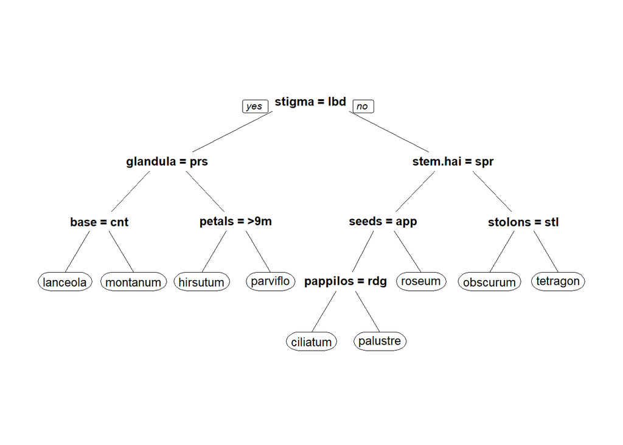

```r
prp(fit)
```

```r
### Export

sink("Key.txt")
print(fit)
sink()
```

## Fenologia

### phenoHist

Esta função irá gerar histogramas circulares de fenologia. Ela é baseada em funções do pacote “circular”. A função requer um “data.frame” com três colunas, ordenadas como: espécie, mês, e fenologia. A coluna do mês deve ser numérica (número do mês), enquanto que na coluna da fenologia os seguintes valores devem ser listados: “Flower”, “Fruit” e/ou “Both”. Se algum destes valores estiverem faltando é possível indicar nos argumentos “flower”, “fruit” e “both” (e.g., both=“missing”). A função irá plotar as barras representando o número de observações com flores em branco, e em frutos em cinza. É possível modificar estas cores com os argumentos: “flower.col”, “flower.border”, “fruit.col” e “fruit.border”. O tamanho das barras representa o número de observações. Os argumentos “shrink”, “axis.cex” e “title.cex” controlam tamanhos, enquanto que “mfrow” modifica o número de histogramas plotados na mesma figura (linhas, colunas).

[Pacote *circular*](https://cran.r-project.org/web/packages/circular/circular.pdf)

*Importando os dados*

```r
data <- read.csv("phenology_model.csv")
```

*Este é o formato da tabela:*

| Species | Month | Phenology |
| --- | --- | --- |
| Smithia glabra | 1 | Flower |
| Smithia glabra | 1 | Flower |
| Smithia glabra | 1 | Flower |
| Smithia glabra | 2 | Both |
| Smithia glabra | 4 | Flower |

Para **rodar** a função simplesmente digite o comando abaixo. A função irá plotar os histogramas. Para exportar um pdf, coloque “pdf = TRUE”.

```r
phenoHist(data, shrink = 1.1, axis.cex = 0.8, title.cex = 1, pdf = FALSE)
```

*Este é o output:*

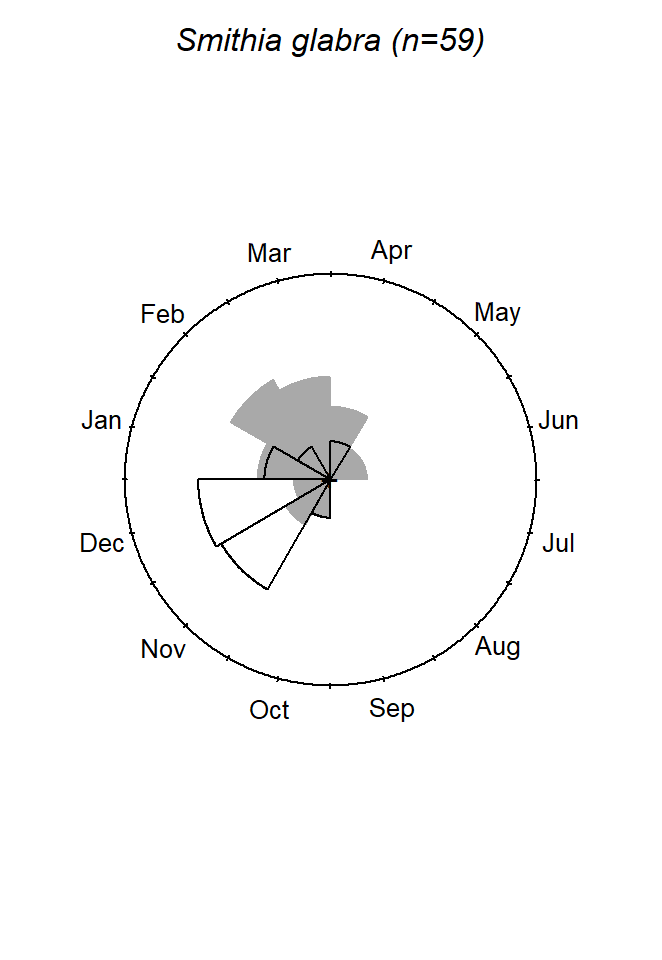

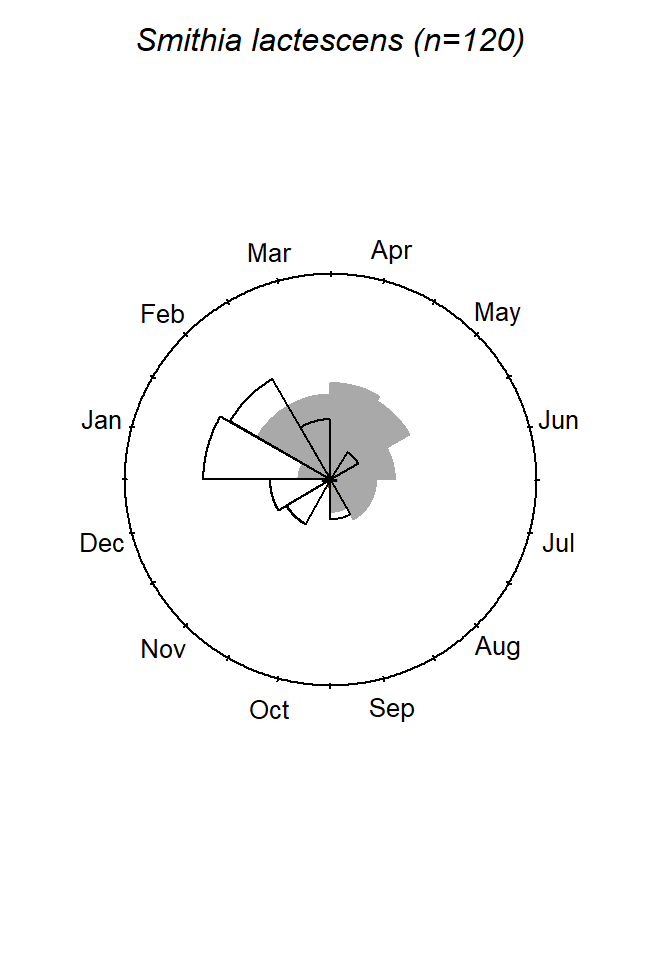

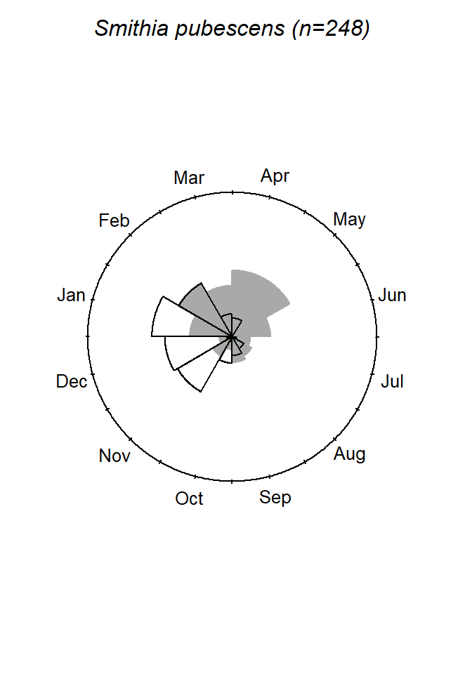

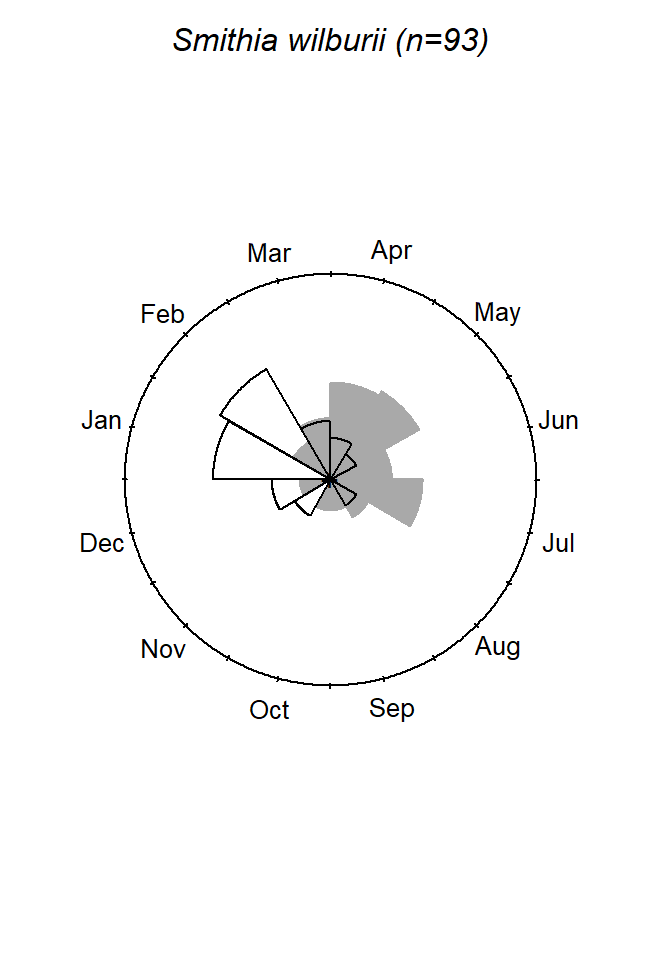

*Veja o help da função para algumas opções de customização.* Digite:

- help(“phenoHist”)

## Mapas

Para a confecção dos mapas iremos utilizar três camadas. Faça o download delas em:

https://sites.google.com/site/biochartis/

https://www.naturalearthdata.com/downloads/50m-raster-data/50m-manual-shaded-relief/

https://www.naturalearthdata.com/downloads/50m-raster-data/50m-cross-blend-hypso/

### Mapas no R

Existem diversos tutoriais para elaboração de mapas no R. Segue o link de dois:

http://www.molecularecologist.com/2012/09/making-maps-with-r/

https://github.com/Robinlovelace/Creating-maps-in-R

### Criando um mapa no R

```r
### Importando os pontos

read.csv("map_functions_model.csv") -> dat

### Importando um shapefile

readShapeSpatial("Lowenberg_Neto_2014.shp") -> areas


### Usando o shapefile mundi do pacote maptools
data("wrld_simpl")

### Plotando um shapefile

plot(areas)
plot(wrld_simpl)

### Importando um raster

raster("MSR_50M.tif") -> relevo

### Plotando o raster

plot(relevo)

### Modificando as cores

gray.colors(255) -> bw.cols

plot(relevo, col=bw.cols, legend=F)

### Modificando o raster

crop(relevo, areas) -> relevo
mask(relevo, areas) -> relevo

plot(relevo, col=bw.cols, legend=F)

### Importando um raster com 3 camadas (RGB)

raster("HYP_50M_SR_W.tif", band=1) -> l1
raster("HYP_50M_SR_W.tif", band=2) -> l2
raster("HYP_50M_SR_W.tif", band=3) -> l3
stack(l1,l2,l3) -> natural

### Plotando o raster RGB

plotRGB(natural)

crop(natural, areas) -> natural

#################################
### Montando o mapa com camadas
#################################

plot(relevo, col=bw.cols, legend=F)
plot(areas, add=T)
points(x=dat$Longitude, y=dat$Latitude, bg="red", col="black", pch=21, cex=1)

## ou

plotRGB(natural)
plot(wrld_simpl, add=T, border="gray20", lty="dotted")
points(x=dat$Longitude, y=dat$Latitude, bg="black", col="white", pch=21, cex=1)

### Exportando uma figura

tiff(filename = "Mapa.tif", width=600, height = 800)
plot(relevo, col=bw.cols, legend=F)
plot(areas, add=T)
points(x=dat$Longitude, y=dat$Latitude, bg="red", col="black", pch=21, cex=1)
dev.off()
```

### mapBatch

Esta função irá exportar mapas para todas as espécies do input. A função é um “wrapper” que utiliza uma série de funções de outros pacotes (e.g. maptools). A função apresenta duas opções de output: um arquivo pdf único com todos os mapas (export = “pdf”) e arquivos individuais tiff (export = “tiff”).  
A função requer um “data.frame” com três colunas ordenadas com: espécie, longitude e latitude. A função apresenta ainda uma série de opções (argumentos) para customização. Por exemplo, se utilizado “zoom = TRUE”, a função irã delimitar o plot utilizando a distribuição de cada espécie; se “zoom = FALSE” todos os mapas apresentarão os mesmos limites (que é o limite de distribuição de todas as espécies combinadas). Cores podem ser trocadas com os argumentos: “points.col”, “shape.col”, e “shape.border”, enquanto que o tamanho dos pontos pode ser alterado com “points.cex”. Uma camada raster pode ser fornecida (e.g., elevação), e as cores do raster são controladas com o argumento “raster.col”. Opcionalmente, é possível fornecer um shapefile ou uma lista contendo shapefiles (type = “user”).

*Importando os dados*

```r
dat <- read.csv("map_functions_model.csv")
```

*Este é o formato da tabela:*

| sp | Longitude | Latitude |
| --- | --- | --- |
| Species_1 | -57.0163 | -28.85189 |
| Species_1 | -49.8600 | -28.80000 |
| Species_1 | -50.0658 | -28.74830 |
| Species_1 | -49.2914 | -28.35890 |
| Species_1 | -48.8700 | -28.08000 |

Para **rodar** a função simplesmente digite o comando abaixo. It will export the maps as a pdf (export = “pdf”) or tiff images (export = “tiff”).

```r
mapBatch(dat, zoom = T, margin = 2, points.col = "black", points.border = "white",
    shape.col = "gray90", points.cex = 1.5, shape.border = "gray90", export = "pdf")
```

*Este é o output:*

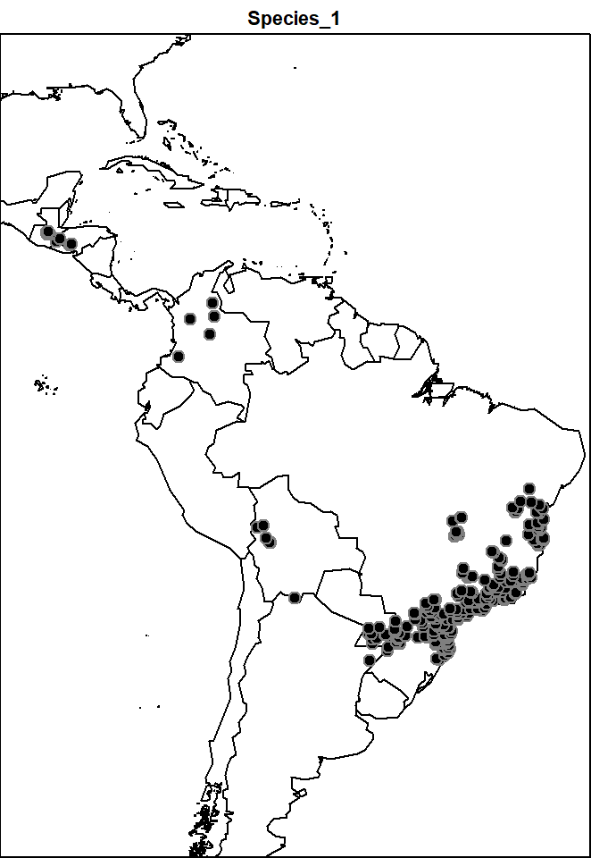

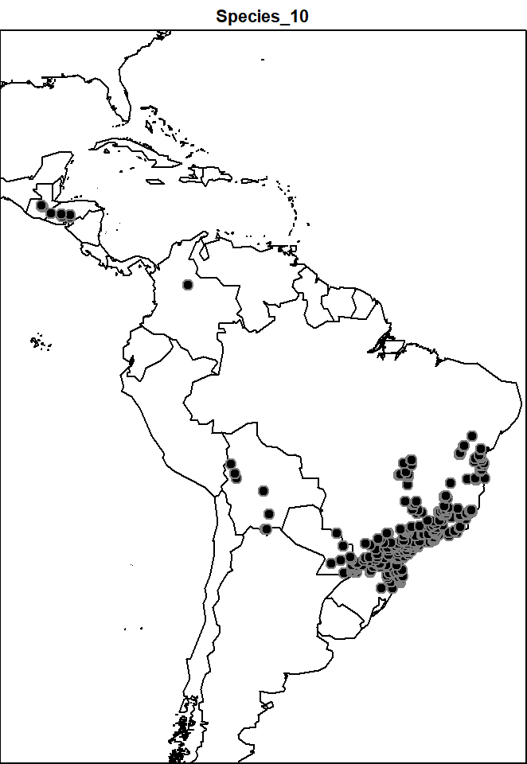

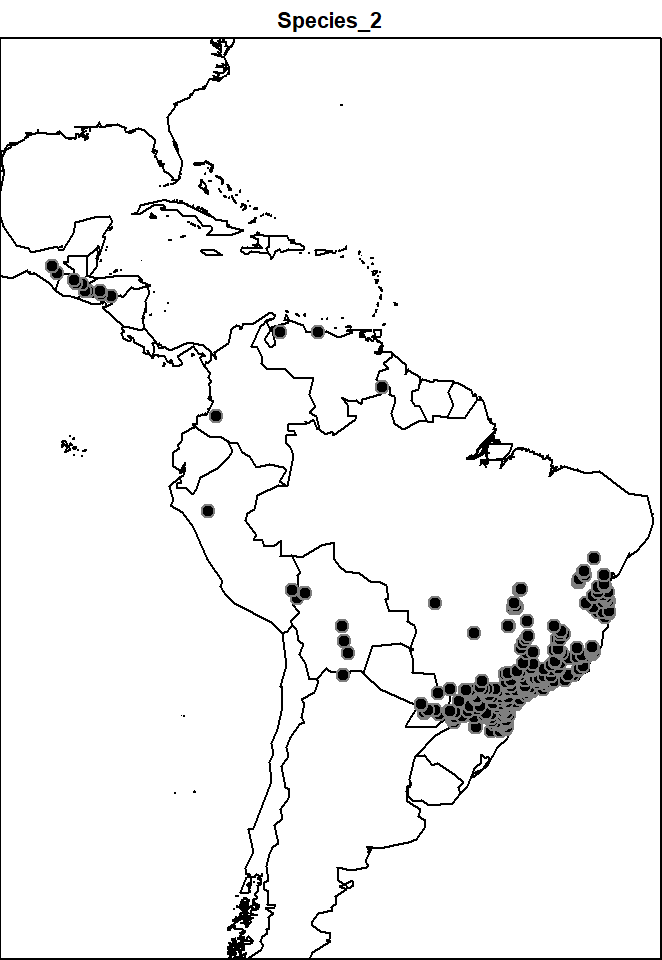

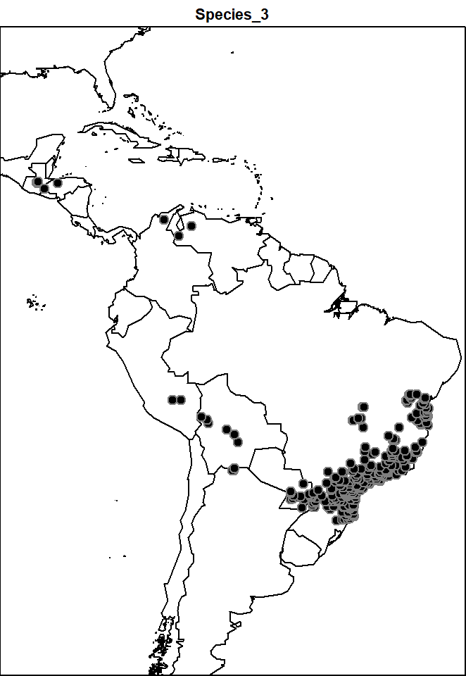

```r
### mapBatch customizado

mapBatch(dat, zoom = F, margin = 0.5, axes = F, shape = areas,
export = "jpeg", raster = relevo, raster.col=bw.cols, points.col = "red",
points.border = "gray50", points.cex = 1, shape.col = NA,
shape.border = "gray50", width = 6, height = 8, box = F)

mapBatch(dat, zoom = T, margin = 0.5, axes = T, shape = areas,
export = "jpeg", raster = relevo, raster.col=bw.cols,
points.col = "red", points.border = "black", points.cex = 1, shape.col = NA,
shape.border = "gray50", width = 6, height = 8, box = T, add.minimap = T, minimap.shape = wrld_simpl, minimap.shape.col = "white", minimap.shape.border = "gray50", minimap.pos = "bottomleft", minimap.add.points = F, minimap.points.col = "black", minimap.points.border = "gray50", minimap.points.cex = 1, minimap.extent = extent(wrld_simpl)/2, hillshade = T)
```

*Veja o help da função para algumas opções de customização.* Digite:

- help(“mapBatch”)

### mapDiversity

Esta função irá gerar um “heatmap” de riqueza com base em presença/ausência de espécies em um grid. A função requer um “data.frame” com três colunas ordenadas com: espécies, longitude e latitude. A função irá plotar e retornar um “raster”. A resolução do grid pode ser modificada com o argumento “resolution” (em graus). A função é um “wrapper” baseado em funções do pacote raster.

*Importando os dados*

```r
dat <- read.csv("map_functions_model.csv")
```

*Este é o formato da tabela:*

| sp | Longitude | Latitude |
| --- | --- | --- |
| Species_1 | -57.0163 | -28.85189 |
| Species_1 | -49.8600 | -28.80000 |
| Species_1 | -50.0658 | -28.74830 |
| Species_1 | -49.2914 | -28.35890 |
| Species_1 | -48.8700 | -28.08000 |

Para **rodar** a função simplesmente digite o comando abaixo. A função irá plotar um “heatmap” de riqueza. É possível também exportar o raster (export=T). Este raster pode ser então visualizado em um programa de GIS.

```r
mapDiversity(dat, resolution = 1, plot = TRUE, plot.with.grid = TRUE, legend = T,
    export = F)
```

*Este é o plot:*

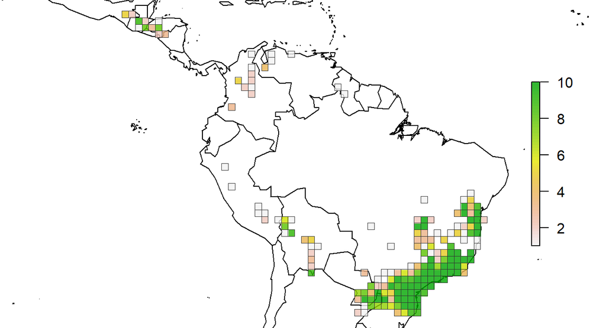

```
## class       : RasterLayer
## dimensions  : 48, 56, 2688  (nrow, ncol, ncell)
## resolution  : 1, 1  (x, y)
## extent      : -94, -38, -30, 18  (xmin, xmax, ymin, ymax)
## coord. ref. : +proj=longlat +datum=WGS84 +ellps=WGS84 +towgs84=0,0,0
## data source : in memory
## names       : layer
## values      : 1, 10  (min, max)
```

*Veja o help da função para algumas opções de customização.* Digite:

- help(“mapDiversity”)

### mapTable

Está função irá gerar uma matriz de presença/ausência em um grid (type=“grid”), em países (type=“countries”) ou em polígonos de uma camada fornecida pelo usuário (type=“user”). A função requer um “data.frame” com três colunas ordenadas com: espécies, longitude e latitude. A resolução do grid pode ser alterada com o argumento “resolution” (em graus). A função é um “wrapper” baseado em funções do pacote raster.

*Importando os dados*

```r
dat <- read.csv("map_functions_model.csv")
```

*Este é o formato da tabela:*

| sp | Longitude | Latitude |
| --- | --- | --- |
| Species_1 | -57.0163 | -28.85189 |
| Species_1 | -49.8600 | -28.80000 |
| Species_1 | -50.0658 | -28.74830 |
| Species_1 | -49.2914 | -28.35890 |
| Species_1 | -48.8700 | -28.08000 |

Para **rodar** a função simplesmente digite o comando abaixo. Neste primeiro exemplo iremos rodar a função com a opção type=“grid”. A função irá retornar uma “lista” com a matriz de presença/ausência e o grid utilizado para sua confecção. É possível exportar os resultados (write.output=T). A arquivo exportado da matriz pode ser visualizado em um programa de planilhas (e.g., Excel) e o grid em um programa de GIS.

```r
map.table <- mapTable(dat, type = "grid", resolution = 3, write.output = FALSE)

map.table$table
```

*Este é o output:*

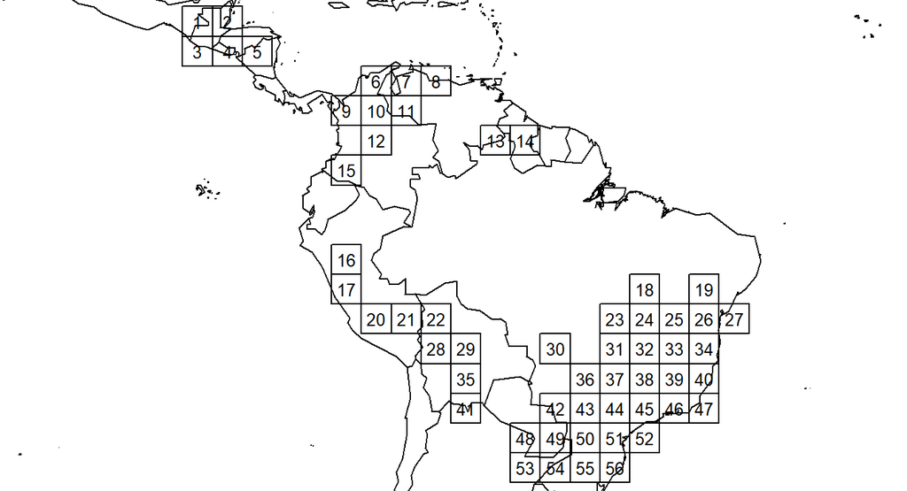

|  | 1 | 2 | 3 | 4 | 5 | 6 | 7 | 8 | 9 | 10 | 11 | 12 | 13 | 14 | 15 | 16 | 17 | 18 | 19 | 20 | 21 | 22 | 23 | 24 | 25 | 26 |
| --- | --- | --- | --- | --- | --- | --- | --- | --- | --- | --- | --- | --- | --- | --- | --- | --- | --- | --- | --- | --- | --- | --- | --- | --- | --- | --- |
| Species_1 | x |  |  | x |  |  |  |  | x | x |  | x |  |  | x |  |  |  | x |  |  | x | x | x | x | x |
| Species_10 | x |  |  | x |  |  |  |  |  | x |  |  |  |  |  |  |  |  | x |  |  | x | x | x |  | x |
| Species_2 | x | x |  | x | x |  | x | x |  |  |  |  | x |  | x | x |  |  | x |  | x | x |  | x |  | x |
| Species_3 | x | x |  | x |  | x | x |  |  |  | x |  |  |  |  |  |  |  |  | x | x |  |  | x |  | x |
| Species_4 | x | x |  | x |  |  |  |  | x | x |  |  |  |  |  |  |  |  | x |  |  |  |  | x | x | x |

```r
### Exemplo com uma camada especificada pelo usuário

mapTable(dat, type="user", layer=areas) -> areas.t

areas.t$Dominions -> areas.d

### Transformar em uma matriz binária

areas.d[areas.d == ""] <- 0
areas.d[areas.d == "x"] <- 1
mode(areas.d) <- "numeric"

### Exportar a matriz

write.csv(areas.d, "areas_matrix.csv")
```

*Veja o help da função para outras opções de customização.* Digite:

- help(“mapTable”)

## Outras funções

[Vignette](https://cran.r-project.org/web/packages/monographaR/vignettes/tutorial.html)

## Script (exemplo)

library(monographaR)

### change your working directory ###  
setwd(“C:/My_working_directory”)

###############################  
##### tableToDescription  
###############################

read.csv(“tableToDescription_data.csv”) -> data  
data[,-1] -> data  
head(data) ## this command just shows the first rows of the table, good to see if it is OK

tableToDescription(data, filename=“species_descriptions.txt”)

###############################  
##### examinedSpecimens  
###############################

read.csv(“examinedSpecimens_data.csv”) -> data  
head(data)

examinedSpecimens(data=data, filename=“examined_material.txt”)

###############################  
##### collectorList  
###############################

read.csv(“collectorList_data.csv”) -> data  
head(data)

collectorList(data, filename=“collector_list.txt”, paragraphs=FALSE)

###############################  
##### buildMonograph  
###############################

read.csv(“headings.csv”) -> taxonomic.headings  
read.csv(“tableToDescription_data.csv”) -> desc.data  
desc.data[,-1] -> desc.data  
read.csv(“examinedSpecimens_data.csv”) -> exam.data  
read.csv(“collectorList_data.csv”) -> col.data

buildMonograph(headings=taxonomic.headings, collectorList.data = col.data, examinedSpecimens.data = exam.data, tableToDescription.data = desc.data, output = “Word”, title=“Monograph skeleton”)